# questao_2

## Titanic - Aprendizado com o desastre

### Contexto

O mais famoso desastre marítimo da história está relatado em tabelas de dados contendo diversas  
informações sobre os passageiros, inclusive quem sobreviveu ou não ao desastre.

### Conteúdo

O seguinte dicionário de dados pode ser usado para melhor entendimento dos atributos.

| Variável | Definição | Chave |
| --- | --- | --- |
| survival | Sobrevivente (classe) | 0 = Não, 1 = Sim |
| pclass | Classe do bilhete | 1 = 1a, 2 = 2a, 3 = 3a |
| sex | Sexo |  |

[output not shown]

```python
import pandas as pd
import numpy  as np
import seaborn as sea
import tensorflow as ts
import chart_studio.plotly as py
import plotly.figure_factory as ff
import matplotlib.pyplot as plt
```

[output not shown]

```python
df = pd.read_csv(r'dados/titanic.csv',sep=',')
```

Grafico de correlação de atributos usando o seaborn

- Removi certos atributos que não me dariam uma correlação alta , e também alguns já mostra que não tem nenhuma como `PassegnerID`
  - `PassegnerID` Primary key : atributo que não repetição

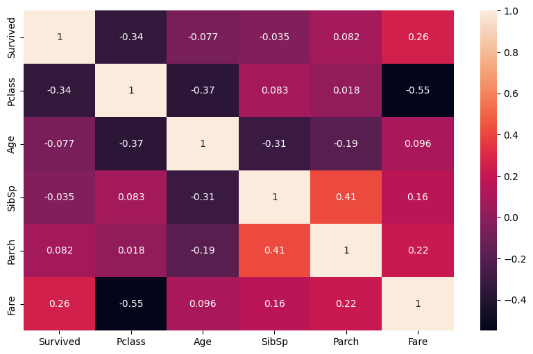

```python
plt.figure(figsize=(10,6))
sea.heatmap((df.drop(columns=['PassengerId','Name','Ticket','Cabin','Embarked','Sex'])).corr(),annot=True)
```

```python
df.describe()
```

|  | PassengerId | Survived | Pclass | Age | SibSp | Parch | Fare |
| --- | --- | --- | --- | --- | --- | --- | --- |
| count | 891.000000 | 891.000000 | 891.000000 | 714.000000 | 891.000000 | 891.000000 | 891.000000 |
| mean | 446.000000 | 0.383838 | 2.308642 | 29.699118 | 0.523008 | 0.381594 | 32.204208 |
| std | 257.353842 | 0.486592 | 0.836071 | 14.526497 | 1.102743 | 0.806057 | 49.693429 |
| min | 1.000000 | 0.000000 | 1.000000 | 0.420000 | 0.000000 | 0.000000 | 0.000000 |
| 25% | 223.500000 | 0.000000 | 2.000000 | 20.125000 | 0.000000 | 0.000000 | 7.910400 |
| 50% | 446.000000 | 0.000000 | 3.000000 | 28.000000 | 0.000000 | 0.000000 | 14.454200 |
| 75% | 668.500000 | 1.000000 | 3.000000 | 38.000000 | 1.000000 | 0.000000 | 31.000000 |
| max | 891.000000 | 1.000000 | 3.000000 | 80.000000 | 8.000000 | 6.000000 | 512.329200 |

Usei pairplot para ver relacao|associcao| em relação a `Survived`

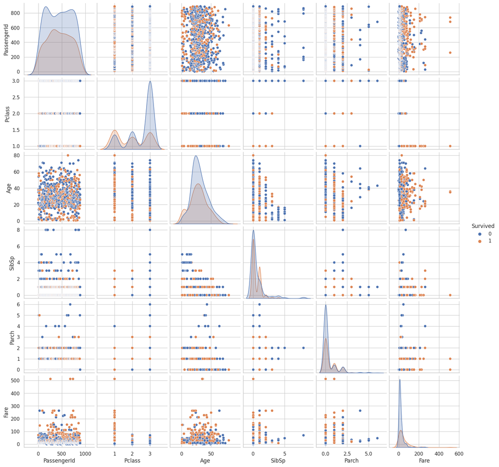

```python
sea.set_theme(style="whitegrid")
sea.pairplot(df,hue='Survived')
```

# Tratamento de dados

Irei converter para valores binario `Embarked e Pclass`

- Usando o get_dummies e colocando o prefixo = embarked_{nome || numero} e definindo o tipo de valor
- Adciono o dummies_embarked e dummies_pclass ao dados mas antes removo os `Embarked e Pclass`
- Removo valores `NaN` no df

```python
dummies_Embarked = pd.get_dummies(df['Embarked'],dtype=int,prefix='Embarked')
dummies_Pclass  =  pd.get_dummies(df['Pclass'],dtype=int,prefix='Pclass')
```

```python
df.drop(columns=['Embarked'],inplace=True)
df.drop(columns=['Pclass'],inplace=True)
df = pd.concat([df,dummies_Embarked],axis=1)
df = pd.concat([df,dummies_Pclass],axis=1)
```

```python
df.dropna(
    subset=['Sex','Age','SibSp','Parch','Fare',
            'Embarked_C','Embarked_Q','Embarked_S',
            'Pclass_1','Pclass_2','Pclass_3'],
    inplace=True
    )
df.shape
```

```
(714, 16)
```

# Classificador

#### Escolhi alguns classficadores e comparei suas acuracias

- knn
- Regressao Logistica
- Decision Tree
- Naive bayes

```python
from sklearn.metrics         import confusion_matrix,ConfusionMatrixDisplay,accuracy_score,classification_report,roc_auc_score,roc_curve
from sklearn.preprocessing   import LabelBinarizer,LabelEncoder
from sklearn.model_selection import train_test_split
from sklearn.linear_model    import LogisticRegression
from sklearn.naive_bayes     import GaussianNB
from sklearn.tree            import DecisionTreeClassifier
from sklearn.neighbors       import KNeighborsClassifier
```

```python
df['Sex'] = LabelBinarizer().fit_transform(df['Sex'])
```

```python
Y = df['Survived'].values
X = df[['Sex','Age','SibSp','Parch','Fare','Embarked_C','Embarked_Q','Embarked_S','Pclass_1','Pclass_2','Pclass_3']].values
```

```python
x_train, x_test, y_train, y_test = train_test_split(X, Y, test_size=0.3,random_state=0)
```

# Regressão Logistica

```python
regressaoLo = LogisticRegression(random_state=0,max_iter=100)
y_pred = regressaoLo.fit(x_train,y_train).predict(x_test)
```

[output not shown]

```python
regressaoLoAcuracia = accuracy_score(y_test,y_pred)
```

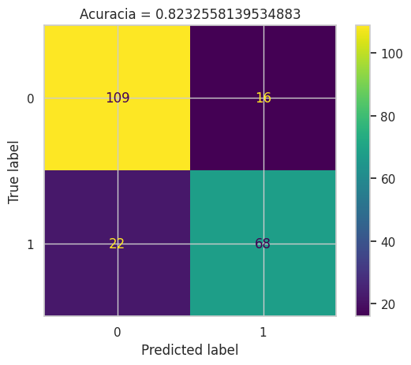

```python
cm = confusion_matrix(y_test,y_pred)

ConfusionMatrixDisplay(cm,display_labels=regressaoLo.classes_).plot()
plt.title(f"Acuracia = {regressaoLoAcuracia}")
```

```python
print(classification_report(y_test,y_pred))
```

```
              precision    recall  f1-score   support

           0       0.83      0.87      0.85       125
           1       0.81      0.76      0.78        90

    accuracy                           0.82       215
   macro avg       0.82      0.81      0.82       215
weighted avg       0.82      0.82      0.82       215
```

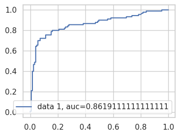

```python
plt.figure(figsize=(4,3))
y_pred_prob    = regressaoLo.predict_proba(x_test)[::,1]
fpr, tpr, null = roc_curve(y_test,   y_pred_prob)
auc            = roc_auc_score(y_test,y_pred_prob)
plt.plot(fpr,tpr,label="data 1, auc="+str(auc))
plt.legend(loc=4)
```

# Arvore de decisão

```python
y_predTree = DecisionTreeClassifier(criterion='entropy').fit(x_train,y_train).predict(x_test)
```

```python
treeAcuracia = accuracy_score(y_test,y_predTree)
```

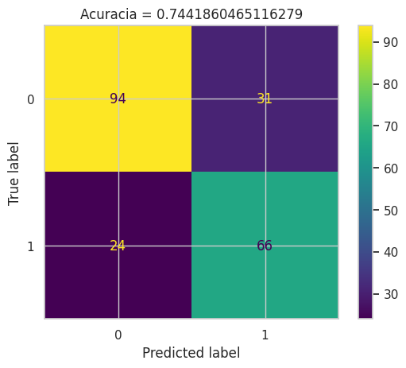

```python
cm = confusion_matrix(y_test,y_predTree)
ConfusionMatrixDisplay(cm,display_labels=regressaoLo.classes_).plot()
plt.title(f"Acuracia = {treeAcuracia}")
```

```python
print(classification_report(y_test,y_predTree))
```

```
              precision    recall  f1-score   support

           0       0.80      0.75      0.77       125
           1       0.68      0.73      0.71        90

    accuracy                           0.74       215
   macro avg       0.74      0.74      0.74       215
weighted avg       0.75      0.74      0.75       215
```

# Naive bayes

```python
y_predBayes = GaussianNB().fit(x_train,y_train).predict(x_test)
```

```python
bayesAcuracia = accuracy_score(y_test,y_predBayes)
```

[figure not shown]

```python
cm = confusion_matrix(y_test,y_predBayes)

ConfusionMatrixDisplay(cm,display_labels=regressaoLo.classes_).plot()
plt.title(f"Acuracia = {treeAcuracia}")
```

```python
print(classification_report(y_test,y_predBayes))
```

```
              precision    recall  f1-score   support

           0       0.79      0.74      0.76       125
           1       0.67      0.73      0.70        90

    accuracy                           0.73       215
   macro avg       0.73      0.73      0.73       215
weighted avg       0.74      0.73      0.74       215
```

# KNN

```python
y_predKnn = KNeighborsClassifier().fit(x_train,y_train).predict(x_test)
```

```python
knnAcuracia = accuracy_score(y_test,y_predKnn)
```

```python
print(classification_report(y_test,y_predKnn))
```

```
              precision    recall  f1-score   support

           0       0.68      0.74      0.71       125
           1       0.59      0.52      0.56        90

    accuracy                           0.65       215
   macro avg       0.64      0.63      0.63       215
weighted avg       0.65      0.65      0.65       215
```

## Comparando classificadores

```python
pd.DataFrame({
    'regressao Logistica':[regressaoLoAcuracia],
    'Arvores de Decisão ':[treeAcuracia],
    'Naives bayes'       :[bayesAcuracia],
    'KNN'                :[knnAcuracia]
},index=['accuracy_score'])
```

|  | regressao Logistica | Arvores de Decisão | Naives bayes | KNN |
| --- | --- | --- | --- | --- |
| accuracy_score | 0.823256 | 0.744186 | 0.734884 | 0.651163 |

> Regressão logistica obteve melhor resultado

# Redes neurais

Testei varias redes. O que mais obtive resultado bom foi usando essa rede

```python
ann = ts.keras.models.Sequential()
```

```python
ann.add(ts.keras.layers.Flatten())
ann.add(ts.keras.layers.Dense(units= 12,activation='relu'))
ann.add(ts.keras.layers.Dense(units= 12,activation='relu'))
ann.add(ts.keras.layers.Dense(units= 8,activation='relu'))
ann.add(ts.keras.layers.Dense(units= 8,activation='relu'))
ann.add(ts.keras.layers.Dense(units= 1,activation='sigmoid'))
```

```python
ann.compile(optimizer = 'adam', loss = 'binary_crossentropy', metrics = ['accuracy'])
```

```python
treino = ann.fit(x_train, y_train, batch_size = 64 ,epochs = 100)
```

```python
y_pred = ((ann.predict(x_test)>0.5)*1).T[0]
```

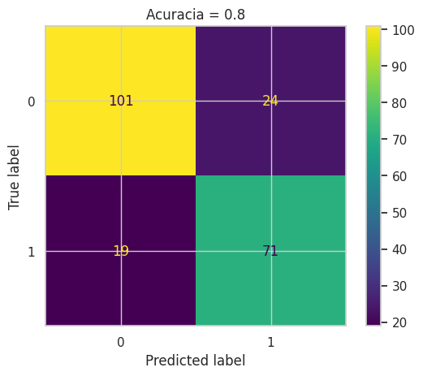

```python
cm = confusion_matrix(y_test,y_pred)

ConfusionMatrixDisplay(cm,display_labels=regressaoLo.classes_).plot()
plt.title(f"Acuracia = {accuracy_score(y_test,y_pred)}")
```